# Relatório Biologia Evolutiva e Estatística

## 2. Calcular os deltaZs em cada ramo

Os deltaZs estimados foram:

```
##              humerus       ulna       femur        tibia
## AC_A      -3.9406415 -7.8481262 -8.46265252 -11.31806792
## AC_C       1.1974884  2.4370812 -2.02820922  -3.08672846
## DB_B      -0.5652248 -1.0714784  2.38515787   3.24721495
## DB_D       1.7501650  3.8026137  4.50283974   6.24632726
## ABCD_AC    0.3823022  0.7309888  1.10696517   1.57105904
## ABCD_DB    0.5072828  1.0482958  0.73195706   0.86574908
## root_E    -0.2209565 -0.8786589 -0.07497944   0.03791358
## root_ABCD  0.8895848  1.7792844  1.83892188   2.43676575
```

A norma de cada um dos oito vetores pode indicidar quais deles tem maior magnitude

```
##       AC_A       AC_C       DB_B       DB_D    ABCD_AC    ABCD_DB
## 16.6384161  4.5841977  4.2072471  8.7644234  2.0914344  1.6252823
##     root_E  root_ABCD
##  0.9099025  3.6437172
```

Os valores de deltaZ sugerem que, na espécie A houve uma redução evolutiva de todas as medidas, enquanto na espécie D um aumento de todas as medidas. A espécie C teve uma redução dos valores dos membros posteriores e aumento dos membros anteriores, em contraste ao que ocorreu na espécie B, que passou por um aumento nos membros posteriores e diminuição dos membros anteriores. A espécie E, por fim, apresentou redução dos membros anteriores e do fêmur e manutenção do tamanho da tíbia. As normas de cada um dos oito vetores mostra que a maior magnitude de mudança evolutiva ocorreu entre o ancestral AC e a espécie A, seguido pelo nó DB e a espécie D, e por fim os nós AC e DB em relação a C e B.

## 3. Estimar as matrizes de var/covar para as espécies ancestrais

```
## $A
##           humerus      ulna     femur     tibia
## humerus 0.8564279 0.7757185 0.2162784 0.2754821
## ulna    0.7757185 1.0863048 0.3172945 0.3577048
## femur   0.2162784 0.3172945 1.0039593 0.7962791
## tibia   0.2754821 0.3577048 0.7962791 1.0678113
##
## $B
##           humerus       ulna      femur     tibia
## humerus 1.0890625 0.44145759 0.17321563 0.1971403
## ulna    0.4414576 0.95318347 0.03739387 0.1376643
## femur   0.1732156 0.03739387 0.92121709 0.6792800
## tibia   0.1971403 0.13766425 0.67928003 1.0532711
##
## $C
##            humerus       ulna      femur     tibia
## humerus 0.98569270 0.75790946 0.01627433 0.3289341
## ulna    0.75790946 0.93666780 0.08537023 0.3363819
## femur   0.01627433 0.08537023 1.19527238 0.1735237
## tibia   0.32893410 0.33638186 0.17352372 0.9117107
##
## $D
##           humerus      ulna     femur     tibia
## humerus 0.9946989 0.7761668 0.5626162 0.5584096
## ulna    0.7761668 0.9981447 0.7903109 0.6367767
## femur   0.5626162 0.7903109 1.1932873 0.6057237
## tibia   0.5584096 0.6367767 0.6057237 0.9119679
##
## $E
##             humerus        ulna      femur     tibia
## humerus  0.96983460 -0.09642127 0.02096006 0.3606990
## ulna    -0.09642127  0.64114545 0.01036461 0.1279602
## femur    0.02096006  0.01036461 0.91131380 0.2485472
## tibia    0.36069899  0.12796018 0.24854724 1.0041185
##
## $AC
##           humerus      ulna     femur     tibia
## humerus 0.9210603 0.7668140 0.1162764 0.3022081
## ulna    0.7668140 1.0114863 0.2013324 0.3470433
## femur   0.1162764 0.2013324 1.0996158 0.4849014
```

[output cut: 12 more lines]

```
## ulna    0.6878131 0.9935752 0.3075924 0.3671319
## femur   0.2420961 0.3075924 1.0784340 0.5637016
## tibia   0.3399915 0.3671319 0.5637016 0.9861903
##
## $root
##           humerus      ulna     femur     tibia
## humerus 0.9791433 0.5309662 0.1978689 0.3441330
## ulna    0.5309662 0.9230892 0.2481468 0.3192976
## femur   0.1978689 0.2481468 1.0450100 0.5006708
## tibia   0.3441330 0.3192976 0.5006708 0.9897759
##
## attr(,"split_type")
## [1] "data.frame"
## attr(,"split_labels")
## [1] "A"    "B"    "C"    "D"    "E"    "AC"   "DB"   "ABCD" "root"
```

## 4. Calcular as Linhas de Menor Resistência Evolutiva (LLER) pelas PC1s

[output not shown]

[output cut: 60 more lines]

```
## [3,] -0.4735461 -0.6209545 -0.61746872  0.09434977
## [4,] -0.4936148 -0.3980274  0.77193053 -0.04518690
##
##
## $PCs_root
## eigen() decomposition
## $values
## [1] 2.0572035 0.9683909 0.5042456 0.4071784
##
## $vectors
##            [,1]       [,2]       [,3]       [,4]
## [1,] -0.4983111  0.5360327  0.1008343  0.6739344
## [2,] -0.4881012  0.4427451 -0.3630440 -0.6587359
## [3,] -0.4801599 -0.6365344 -0.5561452  0.2344631
## [4,] -0.5318739 -0.3338708  0.7407658 -0.2385508
```

Somente as PC1s de cada espécies

```
## $A
## [1] -0.4343108 -0.5278010 -0.4971702 -0.5344362
##
## $B
## [1] -0.4651332 -0.3379125 -0.5384870 -0.6160341
##
## $C
## [1] -0.6308922 -0.6222869 -0.1796760 -0.4271423
##
## $D
## [1] -0.4799671 -0.5366542 -0.5321935 -0.4454256
##
## $E
## [1] 0.57665707 0.05213585 0.37307314 0.72495856
##
## $AC
## [1] -0.5240177 -0.5784481 -0.3976421 -0.4823733
##
## $DB
## [1] 0.4935730 0.4915316 0.5185228 0.4958997
##
## $ABCD
## [1] -0.5027605 -0.5285171 -0.4735461 -0.4936148
##
## $root
## [1] -0.4983111 -0.4881012 -0.4801599 -0.5318739
```

Somente as PC2s:

```
## $A
## [1]  0.5012645  0.5309030 -0.4935434 -0.4725366
##
## $B
## [1]  0.5795610  0.5807624 -0.4138259 -0.3944264
##
## $C
## [1]  0.2234071  0.1475096 -0.9526557 -0.1441434
##
## $D
## [1]  0.63676972  0.11456369 -0.75811489  0.08161674
##
## $E
## [1]  0.61959093 -0.27558638 -0.72836546 -0.09819867
##
## $AC
## [1]  0.4419110  0.4018909 -0.7064509 -0.3796386
##
## $DB
## [1]  0.5703395  0.4394443 -0.5205997 -0.4588873
##
## $ABCD
## [1]  0.5081048  0.4447686 -0.6209545 -0.3980274
##
## $root
## [1]  0.5360327  0.4427451 -0.6365344 -0.3338708
```

Agora podemos comparar as componentes principais entre as espécies.

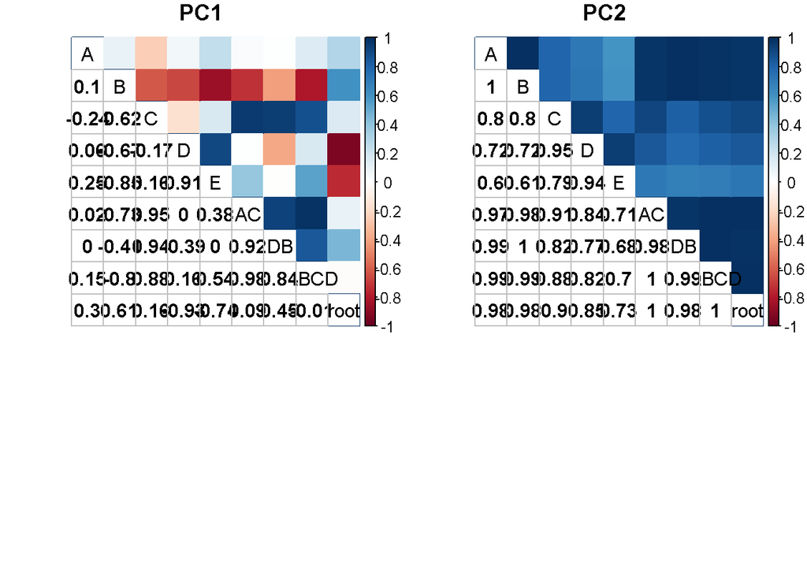

## 5. Comparar as LLERs com os deltaZs realizados em cada ramo

Vamos comparar os valores de deltaZ com a LLER (PC1) em cada ramo

```
##           corr
## A    0.9682337
## B    0.6321950
## C    0.1285191
## D    0.9195546
## E    0.1909136
## AC   0.8707828
## DB   0.9687626
## ABCD 0.9499278
```

Agora vamos comparar os valores da mudança evolutiva (deltaZ) com a PC2 em cada ramo

```
##            corr
## A    0.20332406
## B    0.76479560
## C    0.65532451
## D    0.15446213
## E    0.17159327
## AC   0.43784783
## DB   0.01744123
## ABCD 0.23833198
```

## 6. Calcular matrizes de var/covar dentro e entre grupos para compará-los

As matrizes reconstruídas entre e dentro de grupos pode ser observada abaixo.

Entre grupos:

```
##           humerus     ulna     femur    tibia
## humerus  5.332994 10.97932  9.538405 12.58402
## ulna    10.979322 22.66342 19.796696 26.12068
## femur    9.538405 19.79670 23.765256 31.70954
## tibia   12.584021 26.12068 31.709543 42.34168
```

Dentro de grupos:

```
##           humerus      ulna     femur     tibia
## humerus 0.9791433 0.5309662 0.1978689 0.3441330
## ulna    0.5309662 0.9230892 0.2481468 0.3192976
## femur   0.1978689 0.2481468 1.0450100 0.5006708
## tibia   0.3441330 0.3192976 0.5006708 0.9897759
```

A correlação entre os PC1s entre em relação a dentro dos grupos resulta em:

```
## [1] 0.9502795
```

A correlação entre os PC2s entre em relação a dentro dos grupos resulta em:

```
## [1] 0.8694958
```

A razão entre a magnitude das PC1s entre e dentro dos grupos resulta em:

```
## [1] 42.82924
```

A razão entre a magnitude das PC2s entre e dentro dos grupos resulta em:

```
## [1] 6.172676
```

Com estes resultados podemos observar que embora alinhadas, as variações entre as componentes principais entre e dentro de grupos não são proporcionais, de modo que há variação muito maior entre os grupos do que dentro dos grupos. Este resultado nos leva a rejeitar a hipótese nula de que a diversificação morfológica de *Dentus* tenha se dado principalmente por deriva genética.